# Supplementary Analysis - Initial Traits & Common Species

Julius

2024-01-25

## Load packages

```r
library(tidyverse)
library(data.table)
library(patchwork)
library(flextable)
```

```r
set_flextable_defaults(
  font.size = 10, theme_fun = theme_vanilla,
  padding = 6,
  font.family = "Arial")
```

## Load data

```r
counts_16_seq<-read_csv("../Data/sequencing_counts and metadata.csv", )
EVO_Trait <- read_tsv("../Data/Evolved Initial Traits AMiGA.txt")
ANC_Trait <- read_tsv("../Data/Ancestral Initial Traits AMiGA.txt")
```

## Calculate relative frequencies from 16s rRNA amplicon-sequencing counts

```r
rel_frequencies <- counts_16_seq %>%
  mutate(prey_history = str_replace_all(prey_history, c("ANC" = "Anc.prey", "EVO" = "Evo.prey")),
         predator_history = str_replace_all(predator_history, c("ANC" = "Anc.predator", "EVO" = "Evo.predator"))) %>%
  filter(!time_days == 0) %>%

  group_by(prey_history, predator_history, replicate, time_days)  %>%
  mutate(rel_abundance = count/sum(count)) %>%
  dplyr::select(-sample, -transfer_volume, -old_sample_number)%>%
  ungroup()
```

## Rare & common species in the bacterial communities

Identify rare species that have an average (across all time points) relative abundance below 1% in a community. Theses rare species are selected and the fraction of microcosm in which they were is given. A value of 1 indicates they were rare (<1%) in all of 18 microcosms.

```r
rare_species <- rel_frequencies %>%
  group_by(strainID,prey_history, predator_history, replicate) %>%
  reframe(mean_rel_abundance = mean(rel_abundance)) %>%
  filter(mean_rel_abundance < 0.01) %>%
  group_by(strainID) %>%
  reframe(frac_replicates_rare = n()/18)

ft_rare_species <- flextable(rare_species)
ft_rare_species <- set_caption(ft_rare_species, "proportion of microcosms with species <1%",
  style = "Table Caption")

ft_rare_species
```

proportion of microcosms with species <1%

| strainID | frac_replicates_rare |
| --- | --- |
| HAMBI-0006 | 1.0000000 |
| HAMBI-0097 | 1.0000000 |
| HAMBI-0105 | 0.2777778 |
| HAMBI-0262 | 1.0000000 |
| HAMBI-0403 | 0.2222222 |
| HAMBI-1279 | 1.0000000 |
| HAMBI-1299 | 1.0000000 |
| HAMBI-1842 | 1.0000000 |
| HAMBI-1896 | 0.4444444 |
| HAMBI-1988 | 1.0000000 |
| HAMBI-2159 | 1.0000000 |
| HAMBI-2160 | 0.8888889 |
| HAMBI-2164 | 1.0000000 |
| HAMBI-2443 | 1.0000000 |
| HAMBI-2494 | 1.0000000 |
| HAMBI-2792 | 1.0000000 |
| HAMBI-3031 | 1.0000000 |
| HAMBI-3237 | 1.0000000 |

```r
save_as_image(ft_rare_species,"../Results/rare_species.png")
```

```
## [1] "../Results/rare_species.png"
```

Conversely we identify species that are common (>1%).

```r
common_species <- rel_frequencies %>%
  group_by(strainID,prey_history, predator_history, replicate) %>%
  reframe(mean_rel_abundance = mean(rel_abundance)) %>%
  filter(mean_rel_abundance > 0.01) %>%
  group_by(strainID) %>%
  reframe(frac_replicates_common = n()/18)

ft_common_species <- flextable(common_species)
ft_common_species <- set_caption(ft_common_species, "proportion of microcosms with species >1%",
  style = "Table Caption")

ft_common_species
```

proportion of microcosms with species >1%

| strainID | frac_replicates_common |
| --- | --- |
| HAMBI-0105 | 0.7222222 |
| HAMBI-0403 | 0.7777778 |
| HAMBI-1287 | 1.0000000 |
| HAMBI-1292 | 1.0000000 |
| HAMBI-1896 | 0.5555556 |
| HAMBI-1923 | 1.0000000 |
| HAMBI-1972 | 1.0000000 |
| HAMBI-1977 | 1.0000000 |
| HAMBI-2160 | 0.1111111 |
| HAMBI-2659 | 1.0000000 |

```r
save_as_image(ft_common_species,"../Results/common_species.png")
```

```
## [1] "../Results/common_species.png"
```

8 species can be considered common in most microcosms.

HAMBI-1896 is common in roughly half of the microcosms.

Which species are common depending on predator presence?

We determine the fraction of microcosms with and without predators in which species are common. If the resulting value is NA for a predator condition the species is rare in all microcosm of this predator condition.

```r
common_species_with_predator <- rel_frequencies %>%
  group_by(strainID,prey_history, predator_history, replicate) %>%
  reframe(mean_rel_abundance = mean(rel_abundance)) %>%
  filter(mean_rel_abundance > 0.01) %>%
  group_by(strainID, predator_history) %>%
  reframe(frac_replicates_common = n()/6) %>%
  pivot_wider(names_from = predator_history, values_from = frac_replicates_common)

ft_common_species_with_predator <- flextable(common_species_with_predator)
ft_common_species_with_predator <- set_caption(ft_common_species_with_predator, "proportion of microcosms with species >1% depending on predator presence",
  style = "Table Caption")

ft_common_species_with_predator
```

proportion of microcosms with species >1% depending on predator presence

| strainID | Anc.predator | Evo.predator | no_predator |
| --- | --- | --- | --- |
| HAMBI-0105 | 1.0000000 | 1.0000000 | 0.1666667 |
| HAMBI-0403 | 0.8333333 | 0.6666667 | 0.8333333 |
| HAMBI-1287 | 1.0000000 | 1.0000000 | 1.0000000 |
| HAMBI-1292 | 1.0000000 | 1.0000000 | 1.0000000 |
| HAMBI-1896 | 0.6666667 | 1.0000000 |  |
| HAMBI-1923 | 1.0000000 | 1.0000000 | 1.0000000 |
| HAMBI-1972 | 1.0000000 | 1.0000000 | 1.0000000 |
| HAMBI-1977 | 1.0000000 | 1.0000000 | 1.0000000 |
| HAMBI-2160 | 0.3333333 |  |  |
| HAMBI-2659 | 1.0000000 | 1.0000000 | 1.0000000 |

```r
save_as_image(ft_common_species_with_predator,"../Results/common_species_depending_predator.png")
```

```
## [1] "../Results/common_species_depending_predator.png"
```

HAMBI 0105 and 1896 are common in predator presence but rare in predator absence.

How frequent are those species for which we found variants in the meta-genomic data?

```r
ft_species_w_variants <- counts_16_seq %>%
  mutate(prey_history = str_replace_all(prey_history, c("ANC" = "Anc.prey", "EVO" = "Evo.prey")),
         predator_history = str_replace_all(predator_history, c("ANC" = "Anc.predator", "EVO" = "Evo.predator"))) %>%
  filter(time_days == 0) %>%

  group_by(prey_history, predator_history, replicate, time_days)  %>%
  mutate(rel_abundance = count/sum(count)) %>%
  dplyr::select(-sample, -transfer_volume, -old_sample_number)%>%
  ungroup() %>%
  filter(predator_history != "no_predator" ) %>%
  group_by(strainID) %>%
  reframe(mean_rel_abundance = mean(rel_abundance)) %>%
  dplyr::filter(strainID  %in% c("HAMBI-1287","HAMBI-1972","HAMBI-1977","HAMBI-2659")) %>%
  flextable()

ft_species_w_variants <- set_caption(ft_species_w_variants, "Average rel. abundance of species with detected variants in meta-genomic data",
  style = "Table Caption")

ft_species_w_variants
```

Average rel. abundance of species with detected variants in meta-genomic data

| strainID | mean_rel_abundance |
| --- | --- |
| HAMBI-1287 | 0.038289293 |
| HAMBI-1972 | 0.045869819 |
| HAMBI-1977 | 0.008624748 |
| HAMBI-2659 | 0.008818434 |

```r
save_as_image(ft_species_w_variants,"../Results/frequency_species_with_variants.png")
```

```
## [1] "../Results/frequency_species_with_variants.png"
```

## Initial Traits

1. Matching the column names of EVO and ANC Trait to the ones used in 16s-rRNA counts

```r
##
colnames(EVO_Trait) <-c("strainID","prey_history", "growth", "pred_treatment", "defence") #, "genus", "species"
colnames(ANC_Trait) <-c("strainID","prey_history", "growth", "pred_treatment", "defence")#, "genus", "species"
```

2. Join initial ancestral and evolved traits

```r
init_traits <- rbind(ANC_Trait, EVO_Trait)


delta_anc_evo <- init_traits %>%
  pivot_wider(id_cols = c("strainID"), values_from = c("growth","defence"), names_from = c("prey_history")) %>%
  reframe(strainID = strainID,
          delta_df = defence_EVO - defence_ANC,
          delta_growth = growth_EVO - growth_ANC) %>%
print(n=100)
```

```
## # A tibble: 24 × 3
##    strainID   delta_df delta_growth
##    <chr>         <dbl>        <dbl>
##  1 HAMBI-0006   0.760     -0.173
##  2 HAMBI-0097   0.383     -0.0825
##  3 HAMBI-0105  -0.0970     0.00150
##  4 HAMBI-0262  -0.150      0.0445
##  5 HAMBI-0403   0.442      0.165
##  6 HAMBI-1279   0.585      0.000500
##  7 HAMBI-1287  -0.0625    -0.0180
##  8 HAMBI-1292  -0.0309     0.702
##  9 HAMBI-1299   0.293     -0.0205
## 10 HAMBI-1842   0.435      0.307
## 11 HAMBI-1896   0.880      0.0140
## 12 HAMBI-1923  -0.236      0.0345
## 13 HAMBI-1972   0.638     -0.00300
## 14 HAMBI-1977   0.103     -0.0610
## 15 HAMBI-1988  -0.830      0.234
## 16 HAMBI-2159   0.870     -0.0995
## 17 HAMBI-2160  -0.333      0.068
## 18 HAMBI-2164  -0.476      0.167
## 19 HAMBI-2443  -0.601      0.340
## 20 HAMBI-2494  -0.0137     0.0205
## 21 HAMBI-2659  -0.264      0.094
## 22 HAMBI-2792  -1.16       0.313
## 23 HAMBI-3031  -1.11       0.328
## 24 HAMBI-3237  -0.385      0.136
```

```r
delta_anc_evo %>%
filter( strainID == common_species$strainID)
```

```
## # A tibble: 0 × 3
## # ℹ 3 variables: strainID <chr>, delta_df <dbl>, delta_growth <dbl>
```

3. Visualise initial traits

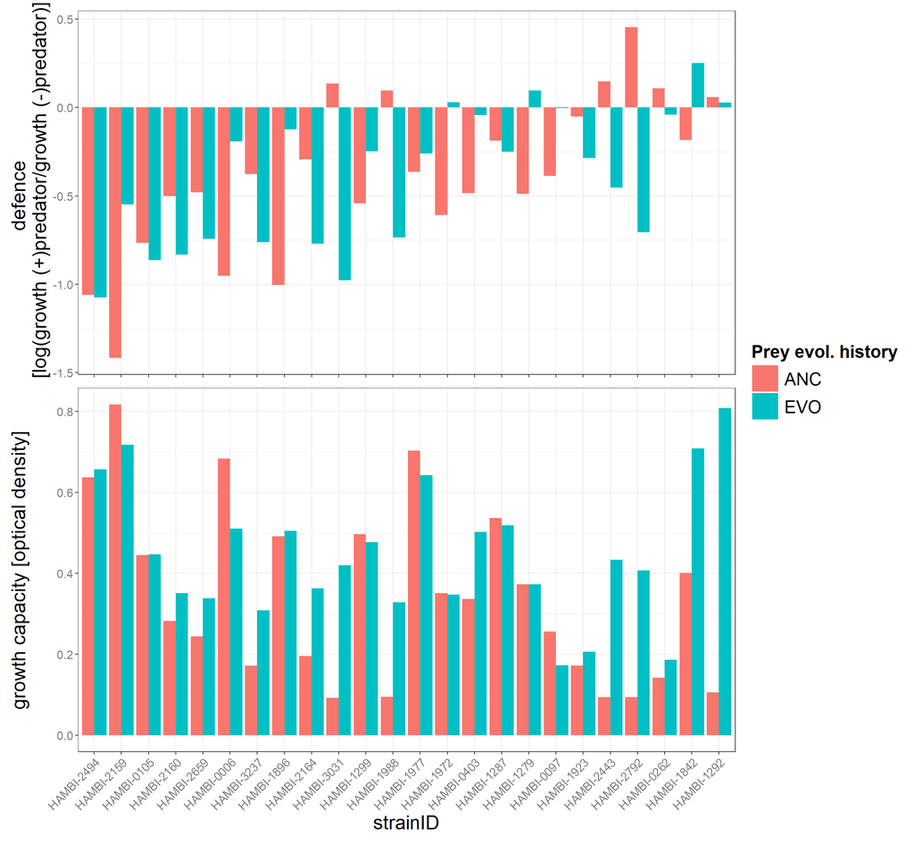

```r
init_defence /init_growth + plot_layout(guides = "collect")
```

```r
ggsave("Initial_traits_Anc_Evo.pdf", device = "pdf", path = "../Results", width = 270, height = 270,  units = "mm")
```

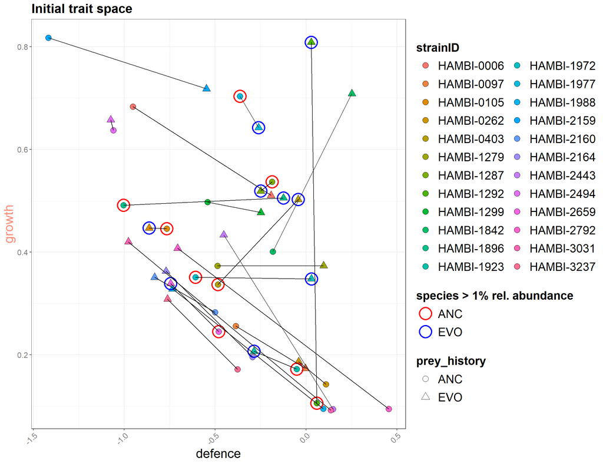